GUID: 2557756 https://github.com/emilylonie/AI_Arts_A_23-24

# Week 1: Getting started with Python, Jupyter Notebook and Anaconda

Exercises to familarise myself with Jupyter Notebook and it's relation to Python

### Task 1

### a) Why you chose to join this course – for, motivation, vision, aspiration?

I chose to join this course as I think learning some Python will be a useful skill. And I find the impact of AI on the Humanities interesting.

### b) Prior experience, if any, you have with AI and/or Python

My experience with AI is from other classes, I took Introduction to the Digital Humanities last year which touched on the use of AI within the humanities. I have also had a little previous experience with Python in previous studies.

### c) What you expect to learn from the course

- I expect to pick up on some Python language and knowledge and be able to apply this to the humanities work.
- I expect to learn current developments in AI and associated applications
- I expect to learn an overview of AI history and development

**Success:** I have now completed my markdown cells and can start coding!

### Task 2.1

```python
print ("Hello, world!") #The print function outputs the code in the ("")
```

```
Hello, world!
```

```python
message = "Hello, world!" #The message variable pre-defines the string 'hello, world!'
print (message)
```

```
Hello, world!
```

```python
message2 = "Hello, autumn!"
print (message2)
```

```
Hello, autumn!
```

```python
print (message + " " + message2)  #Here, + joins strings together while " " acts as a space
```

```
Hello, world! Hello, autumn!
```

```python
print (message2*3)  #*3 repeats the string 3 times
```

```
Hello, autumn!Hello, autumn!Hello, autumn!
```

```python
print ((message2 + " ")*3)
```

```
Hello, autumn! Hello, autumn! Hello, autumn!
```

```python
print (message[0]) #[0] prints the first element in the string
```

```
H
```

```python
print (message2[7:13]) #[7:13] prints the elements in the string between positions 7 and 13
```

```
autumn
```

### Task 2.2

```python
from IPython.display import *  #imports a python library which is capable of displaying youtube videos
YouTubeVideo("AqAJLh9wuZ0")  #Video sourced from youtube
```

[video not shown]

### Task 2.3

```python
import webbrowser #importing the web broswer library
import requests #importing requests library

print("Shall we hunt down an old website?") #printing string
site = input("Type a website URL: ") #assigning a value to "site" variable
era = input("Type year, month, and date, e.g., 20150613: ") #assigning a value to "era" variable
url = "http://archive.org/wayback/available?url=%s&timestamp=%s" % (site, era) #assigning a value to "url" variable
response = requests.get(url) #assigning a value to "response" variable
data = response.json() #assigning a value to "data" variable
try: #the following block may fail if it is unable to open the web broswer or the data response doesn't exist
    old_site = data["archived_snapshots"]["closest"]["url"] #assigning a value to "old_site" variable
    print("Found this copy: ", old_site) #printing string output
    print("It should appear in your browser.") #printing string output
    webbrowser.open(old_site) #command to open old_site
except: #if the previous code fails, the next line of code will be computed
    print("Sorry, could not find the site.") #printing string output (failure message)
```

# Week 2: Exploring Data in Multiple Ways

### Task 3.1

```python
from IPython.display import Image  #Imports python function capable of displaying images
Image ("picture1.jpg")  #retrieves an image saved on the computer
```

```python
from IPython.display import Audio  #Imports python function capable of playing audio

Audio ("audio1.mid")  #retrieves a midi file saved on the computer
```

[interactive chart not shown]

```python
Audio ("audio2.ogg")
#This file is licensed under the Creative Commons Attribution-Share Alike 3.0 Unported license.
#You are free:
#•to share – to copy, distribute and transmit the work
#•to remix – to adapt the work
#Under the following conditions:
#•attribution – You must give appropriate credit, provide a link to the license, and indicate if changes were made. You may do so in any reasonable manner, but not in any way that suggests the licensor endorses you or your use.
#•share alike – If you remix, transform, or build upon the material, you must distribute your contributions under the same or compatible license as the original.
#The original ogg file was found at the url:
#https://en.wikipedia.org/wiki/File:GoldbergVariations_MehmetOkonsar-1of3_Var1to10.ogg
```

# Explanation

Audio1.mid will not play as it is a MIDI (Musical Instrument Digital Interface) file. This holds information on how musical instruments should be played, and needs software to translate it. However, Audio2.ogg works as it is compatible with the Python library's software.

### Task 3.2

```
Numpy array of the image is:  [[[207 204 199]
  [208 205 200]
  [209 206 201]
  ...
  [206 207 212]
  [205 206 211]
  [205 206 211]]

 [[206 203 198]
  [207 204 199]
  [208 205 200]
  ...
  [206 207 212]
  [205 206 211]
  [205 206 211]]

 [[205 202 197]
  [206 203 198]
  [207 204 199]
  ...
  [206 207 212]
  [205 206 211]
  [205 206 211]]

 ...

 [[106  90  91]
  [111  97  97]
  [118 104 104]
  ...
  [193 193 203]
  [190 190 200]
  [190 190 200]]

 [[111  97  97]
  [115 101 101]
  [121 107 107]
  ...
  [193 193 203]
  [191 191 201]
  [191 191 201]]

 [[118 104 104]
  [121 107 107]
  [125 110 113]
  ...
  [190 190 200]
  [190 190 200]
  [190 190 200]]]
```

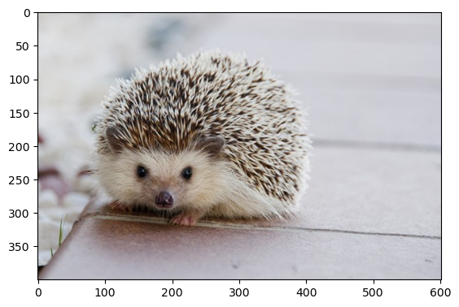

```python
from matplotlib import pyplot  #imports a python library
test_picture = pyplot.imread("picture1.jpg")
print("Numpy array of the image is: ", test_picture)
pyplot.imshow(test_picture)

#this prints numbers representing the RGB values of each pixel
```

```
Clipping input data to the valid range for imshow with RGB data ([0..1] for floats or [0..255] for integers).
```

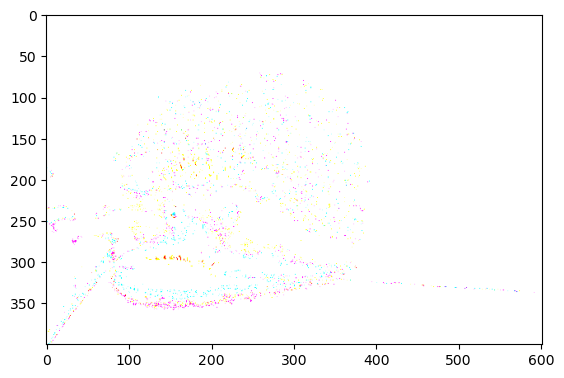

```python
test_picture_filtered = 2*test_picture/3 # / means the data will be converted to floats
pyplot.imshow(test_picture_filtered) #Reffered to as Image1
```

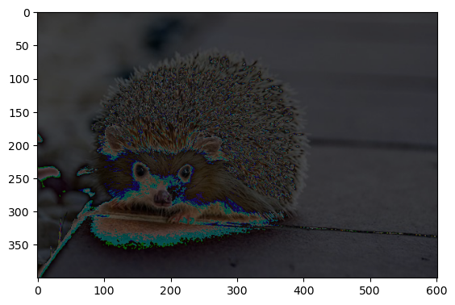

```python
test_picture_filtered = 2*test_picture//3 # // means the data will stay as an integer
pyplot.imshow(test_picture_filtered) #Reffered to as Image2
```

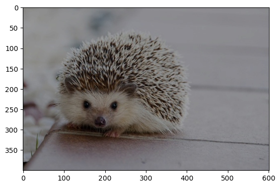

```python
test_picture_filtered = 2*(test_picture//3) #the brackets means the multiplication will not proceed until the divison has finished i.e there will be no overflow
pyplot.imshow(test_picture_filtered) #Reffered to as Image3
```

# Discussion:

Image1*: is displaying incorectly as 2*test_picture/3 is dividing the pixels/RGB data by 3, causing them to turn into decimals/floats. This means that every pixel which is out with the range specified will show a white pixel instead of a coloured one.

Image3: As a double slash is used as well as brackets to keep the division and multiplication seperate, the image is displaying without any errors.

*See comments for image names

### Task 3.3

```python
from sklearn import datasets  #loads the datasets
```

```python
dir(datasets)  #Shows all of the datasets/functions available in the library
```

```
['__all__',
 '__builtins__',
 '__cached__',
 '__doc__',
 '__file__',
 '__getattr__',
 '__loader__',
 '__name__',
 '__package__',
 '__path__',
 '__spec__',
 '_arff_parser',
 '_base',
 '_california_housing',
 '_covtype',
 '_kddcup99',
 '_lfw',
 '_olivetti_faces',
 '_openml',
 '_rcv1',
 '_samples_generator',
 '_species_distributions',
 '_svmlight_format_fast',
 '_svmlight_format_io',
 '_twenty_newsgroups',
 'clear_data_home',
 'dump_svmlight_file',
 'fetch_20newsgroups',
 'fetch_20newsgroups_vectorized',
 'fetch_california_housing',
 'fetch_covtype',
 'fetch_kddcup99',
 'fetch_lfw_pairs',
 'fetch_lfw_people',
 'fetch_olivetti_faces',
 'fetch_openml',
 'fetch_rcv1',
 'fetch_species_distributions',
 'get_data_home',
 'load_breast_cancer',
```

[output cut: 16 more lines]

```
 'make_friedman2',
 'make_friedman3',
 'make_gaussian_quantiles',
 'make_hastie_10_2',
 'make_low_rank_matrix',
 'make_moons',
 'make_multilabel_classification',
 'make_regression',
 'make_s_curve',
 'make_sparse_coded_signal',
 'make_sparse_spd_matrix',
 'make_sparse_uncorrelated',
 'make_spd_matrix',
 'make_swiss_roll',
 'textwrap']
```

For this task I'm going to work with the datasets 'load_wine' as I like wine and 'load_breast_cancer' as womens health is an interesting topic to me

```python
wine_data = datasets.load_wine()
breast_cancer_data = datasets.load_breast_cancer()
#loads 2 different datasets from the library
```

```python
wine_data.DESCR #description of the data in this file
```

```
'.. _wine_dataset:\n\nWine recognition dataset\n------------------------\n\n**Data Set Characteristics:**\n\n    :Number of Instances: 178\n    :Number of Attributes: 13 numeric, predictive attributes and the class\n    :Attribute Information:\n \t\t- Alcohol\n \t\t- Malic acid\n \t\t- Ash\n\t\t- Al…
```

```python
breast_cancer_data.DESCR
```

```python
print (wine_data.DESCR) #Makes the description easier to read!
```

```
.. _wine_dataset:

Wine recognition dataset
------------------------

**Data Set Characteristics:**

    :Number of Instances: 178
    :Number of Attributes: 13 numeric, predictive attributes and the class
    :Attribute Information:
 		- Alcohol
 		- Malic acid
 		- Ash
		- Alcalinity of ash
 		- Magnesium
		- Total phenols
 		- Flavanoids
 		- Nonflavanoid phenols
 		- Proanthocyanins
		- Color intensity
 		- Hue
 		- OD280/OD315 of diluted wines
 		- Proline

    - class:
            - class_0
            - class_1
            - class_2

    :Summary Statistics:

    ============================= ==== ===== ======= =====
                                   Min   Max   Mean     SD
    ============================= ==== ===== ======= =====
    Alcohol:                      11.0  14.8    13.0   0.8
    Malic Acid:                   0.74  5.80    2.34  1.12
    Ash:                          1.36  3.23    2.36  0.27
    Alcalinity of Ash:            10.6  30.0    19.5   3.3
    Magnesium:                    70.0 162.0    99.7  14.3
    Total Phenols:                0.98  3.88    2.29  0.63
```

[output cut: 40 more lines]

```
  Tech. Rep. no. 92-02, (1992), Dept. of Computer Science and Dept. of
  Mathematics and Statistics, James Cook University of North Queensland.
  (Also submitted to Technometrics).

  The data was used with many others for comparing various
  classifiers. The classes are separable, though only RDA
  has achieved 100% correct classification.
  (RDA : 100%, QDA 99.4%, LDA 98.9%, 1NN 96.1% (z-transformed data))
  (All results using the leave-one-out technique)

  (2) S. Aeberhard, D. Coomans and O. de Vel,
  "THE CLASSIFICATION PERFORMANCE OF RDA"
  Tech. Rep. no. 92-01, (1992), Dept. of Computer Science and Dept. of
  Mathematics and Statistics, James Cook University of North Queensland.
  (Also submitted to Journal of Chemometrics).
```

```python
print (breast_cancer_data.DESCR)
```

```python
wine_data.feature_names #by observing the feature names I can conclude that this dataset is trying to analyse what components makes various wines taste different.
```

```python
breast_cancer_data.feature_names #From the featured names I can guess that this dataset is observing the average attributes of the collected data, as well as the most severe instances and errors
```

```python
wine_data.target_names
```

```
array(['class_0', 'class_1', 'class_2'], dtype='<U7')
```

```python
wine_data.keys() #the objects/categories are shown
```

```python
images_data = datasets.load_sample_images()
print (images_data.DESCR)
```

[output not shown]

```python
images_data.keys()
```

```python
images_data.images #shows the data related to the images
```

```python
images_data.filenames #shows the file names of the images
```

### Task 3.4

```python
from sklearn import datasets
import pandas

wine_data = datasets.load_wine()

wine_dataframe = pandas.DataFrame(data=wine_data['data'], columns = wine_data['feature_names'])
```

```python
wine_data.data #Shows the values in the wine dataset in its raw form
```

```
array([[1.423e+01, 1.710e+00, 2.430e+00, ..., 1.040e+00, 3.920e+00,
        1.065e+03],
       [1.320e+01, 1.780e+00, 2.140e+00, ..., 1.050e+00, 3.400e+00,
        1.050e+03],
       [1.316e+01, 2.360e+00, 2.670e+00, ..., 1.030e+00, 3.170e+00,
        1.185e+03],
       ...,
       [1.327e+01, 4.280e+00, 2.260e+00, ..., 5.900e-01, 1.560e+00,
        8.350e+02],
       [1.317e+01, 2.590e+00, 2.370e+00, ..., 6.000e-01, 1.620e+00,
        8.400e+02],
       [1.413e+01, 4.100e+00, 2.740e+00, ..., 6.100e-01, 1.600e+00,
        5.600e+02]])
```

```python
wine_dataframe.head() #when loaded with pandas, the data is formatted... and readable!
```

|  | alcohol | malic_acid | ash | alcalinity_of_ash | magnesium | total_phenols | flavanoids | nonflavanoid_phenols | proanthocyanins | color_intensity | hue | od280/od315_of_diluted_wines | proline |
| --- | --- | --- | --- | --- | --- | --- | --- | --- | --- | --- | --- | --- | --- |
| 0 | 14.23 | 1.71 | 2.43 | 15.6 | 127.0 | 2.80 | 3.06 | 0.28 | 2.29 | 5.64 | 1.04 | 3.92 | 1065.0 |
| 1 | 13.20 | 1.78 | 2.14 | 11.2 | 100.0 | 2.65 | 2.76 | 0.26 | 1.28 | 4.38 | 1.05 | 3.40 | 1050.0 |
| 2 | 13.16 | 2.36 | 2.67 | 18.6 | 101.0 | 2.80 | 3.24 | 0.30 | 2.81 | 5.68 | 1.03 | 3.17 | 1185.0 |
| 3 | 14.37 | 1.95 | 2.50 | 16.8 | 113.0 | 3.85 | 3.49 | 0.24 | 2.18 | 7.80 | 0.86 | 3.45 | 1480.0 |
| 4 | 13.24 | 2.59 | 2.87 | 21.0 | 118.0 | 2.80 | 2.69 | 0.39 | 1.82 | 4.32 | 1.04 | 2.93 | 735.0 |

```python
wine_dataframe.describe() #pandas also allows you to compute statistics about the data
```

|  | alcohol | malic_acid | ash | alcalinity_of_ash | magnesium | total_phenols | flavanoids | nonflavanoid_phenols | proanthocyanins | color_intensity | hue | od280/od315_of_diluted_wines | proline |
| --- | --- | --- | --- | --- | --- | --- | --- | --- | --- | --- | --- | --- | --- |
| count | 178.000000 | 178.000000 | 178.000000 | 178.000000 | 178.000000 | 178.000000 | 178.000000 | 178.000000 | 178.000000 | 178.000000 | 178.000000 | 178.000000 | 178.000000 |
| mean | 13.000618 | 2.336348 | 2.366517 | 19.494944 | 99.741573 | 2.295112 | 2.029270 | 0.361854 | 1.590899 | 5.058090 | 0.957449 | 2.611685 | 746.893258 |
| std | 0.811827 | 1.117146 | 0.274344 | 3.339564 | 14.282484 | 0.625851 | 0.998859 | 0.124453 | 0.572359 | 2.318286 | 0.228572 | 0.709990 | 314.907474 |
| min | 11.030000 | 0.740000 | 1.360000 | 10.600000 | 70.000000 | 0.980000 | 0.340000 | 0.130000 | 0.410000 | 1.280000 | 0.480000 | 1.270000 | 278.000000 |
| 25% | 12.362500 | 1.602500 | 2.210000 | 17.200000 | 88.000000 | 1.742500 | 1.205000 | 0.270000 | 1.250000 | 3.220000 | 0.782500 | 1.937500 | 500.500000 |
| 50% | 13.050000 | 1.865000 | 2.360000 | 19.500000 | 98.000000 | 2.355000 | 2.135000 | 0.340000 | 1.555000 | 4.690000 | 0.965000 | 2.780000 | 673.500000 |
| 75% | 13.677500 | 3.082500 | 2.557500 | 21.500000 | 107.000000 | 2.800000 | 2.875000 | 0.437500 | 1.950000 | 6.200000 | 1.120000 | 3.170000 | 985.000000 |
| max | 14.830000 | 5.800000 | 3.230000 | 30.000000 | 162.000000 | 3.880000 | 5.080000 | 0.660000 | 3.580000 | 13.000000 | 1.710000 | 4.000000 | 1680.000000 |

### Discussion:

wine_data.data displays all of the data available in the dataset. dataframe.head displays the first few rows of this data in a column (using feature_names as headings dataframe.describe takes the averages and trends from all 178 rows of original data and displays it in a table (i.e provides a summary of the data)